# Using TrIdent

### SpecializedTransduction_ID()

Specialized transduction occurs when a prophage/PICI has an improper excision from the host bacterium’s chromosome and accidentally packages a small portion of bacterial DNA directly outside the prophage/PICI region. `SpecializedTransduction_ID()` searches contigs classified as Prophage-like for dense read coverage outside the borders of the Prophage-like pattern that could represent specialized transduction. Because specialized transduction tends to be fairly short (several kbps) compared to generalized/lateral/gene transfer agent transduction (tens to hundreds of kbps), averaging over a 1000 bp distance (i.e using a `windowsize=1000`) can ‘blur’ specialized transduction patterns depending on their size. This is why specialized transduction is not identified in `TrIdent_Classifier()`. Instead, we use the locations of prophages/PICIs identified with `TrIdent_Classifier()` to guide our search for specialized transduction in `SpecializedTransduction_ID()`.

`SpecializedTransduction_ID()` does not resize the windows of the input pileup files to preserve resolution of potential specialized transduction patterns. Because of this, we can not use the locations of the Prophage-like pattern matches to determine the exact border locations of prophage/PICIs. The locations generated with `TrIdent_Classifier()` using a 1000 bp `windowsize` (or one of the other options) will not perfectly translate back to a `windowsize` of 100. Instead, we use the locations of the Prophage-like pattern matches to’zoom-in’ on the region of a contig where an associated Prophage-like pattern match is located. `SpecializedTransduction_ID` then searches the contig, starting from the left moving inward, for the first coverage value that is at least 20% of the maximum coverage value. This represents the left ‘border’. The search is repeated starting from the right side of the contig moving inwards and the first coverage value that is at least 20% of the maximum value represents the right ‘border’. For contigs that have a Prophage-like match that trails off the side of a contig, then only the border that falls on the contig is searched for.

Once the prophage/PICI borders are identified, `SpecializedTransduction_ID()` starts from the borders and searches outwards for dense read coverage that meet the ‘requirements’ for specialized transduction as defined by the arguments in `SpecializedTransduction_ID()`. `SpecializedTRansducion_ID` uses two arguments to define specialized transduction:

- `noreadcov`
- `spectranslength`

`SpecializedTransduction_ID()` first makes sure that any coverage it detects outside the borders is not disrupted by a defined region of no read coverage (`noreadcov`). The default value for `noreadcov` is 500 bp. Secondly, `SpecializedTransduction_ID` ensures that any read coverage it detects outside of the prophage/PICI borders meets a minimum length requirement (`spectranslength`). The default value for `spectranslength` is 2000 bp. So by default, `SpecializedTransduction_ID()` will search for coverage that is at least 2000 bp long and is not interrupted at any point by more than 500 bp of no read coverage. If these requirements are met, `SpecializedTransduction_ID()` will mark the contig as having specialized transduction.

###### Default:

Search all contigs classified as Prophage-like for specialized transduction:

```r
Specialized_transduction <- SpecializedTransduction_ID(VLPFraction_sampledata, TrIdent_results)
## 2 contigs have potential specialized transduction
```

When you search all contigs, the output of `SpecializedTransduction_ID()` will be a list. The first object contains a summary table for the specialized transduction search results:

```r
SpecializedTransduction_summary_table <- Specialized_transduction$Summary_table
```

| ref_name | Specialized_transduction | Left | Right |
| --- | --- | --- | --- |
| NODE_2 | no | no | no |
| NODE_44 | yes | yes | no |
| NODE_62 | yes | yes | no |
| NODE_125 | no | no | no |

The second object in the output-list contains a list with the resulting read coverage plots for all contigs classified as Prophage-like. The borders of the prophage/PICI as identified by `SpecializedTransduction_ID()` are marked on each plot with a black vertical line. If `SpecializedTransduction_ID()` identifies potential specialized transduction, it will color the plot green whereas if does not identify any specialized transduction, it will color the plot blue. The end of specialized transduction as determined by `SpecializedTransduction_ID` will be marked with a red vertical line. Each plot is named by the associated contig accession.

View all the plots:

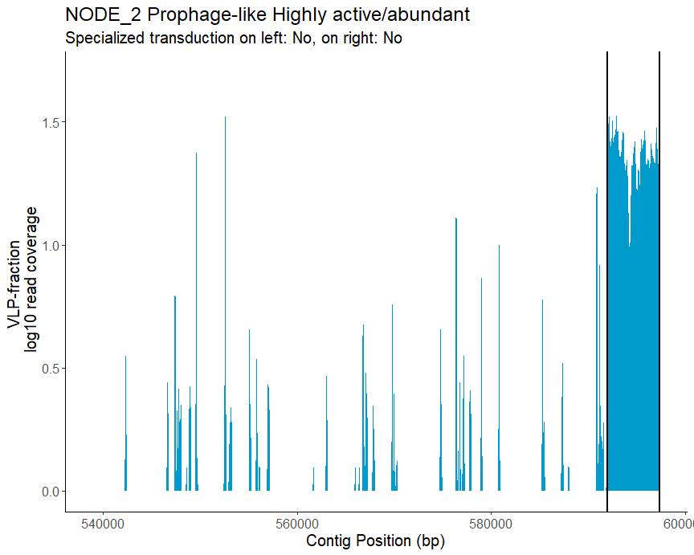

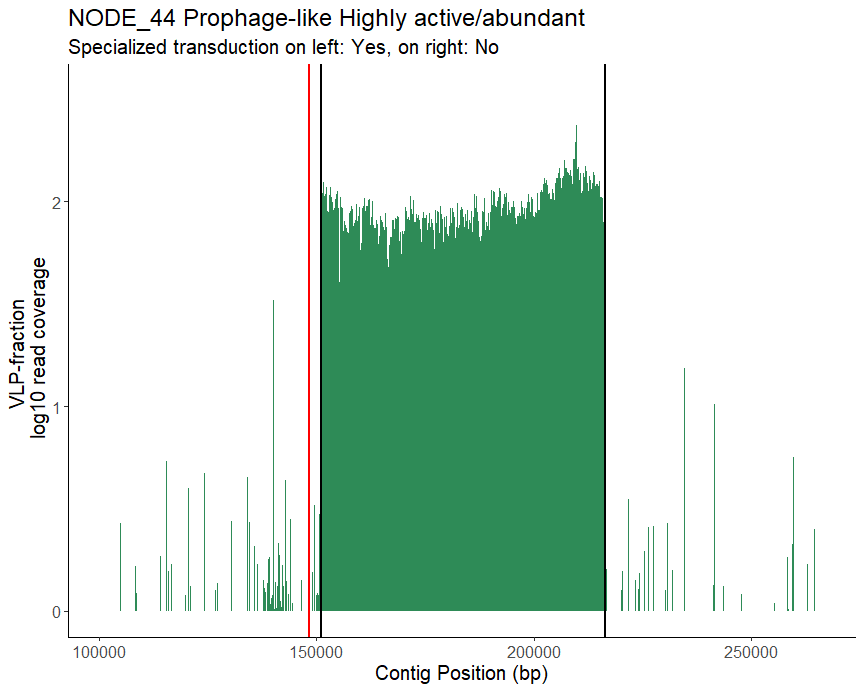

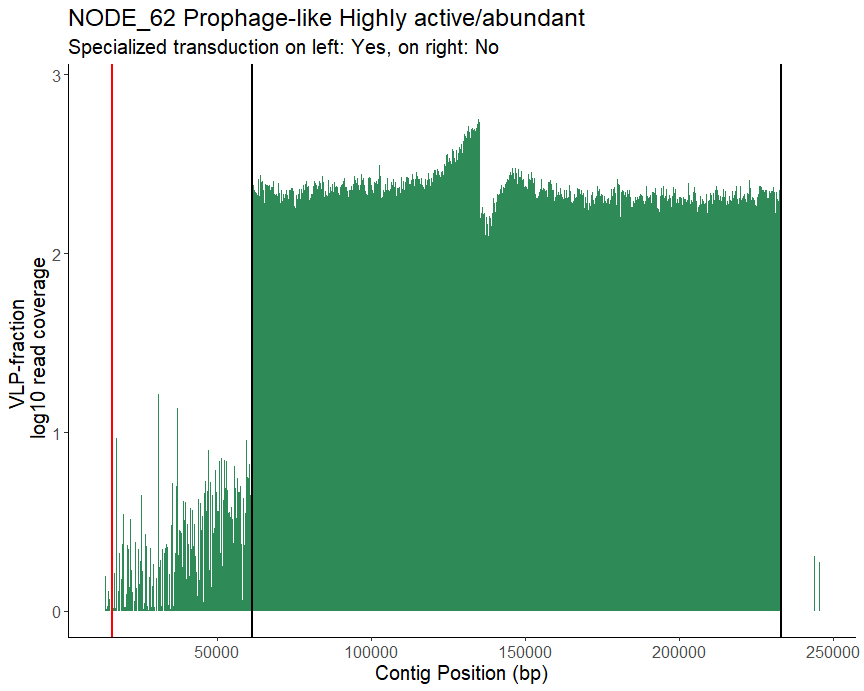

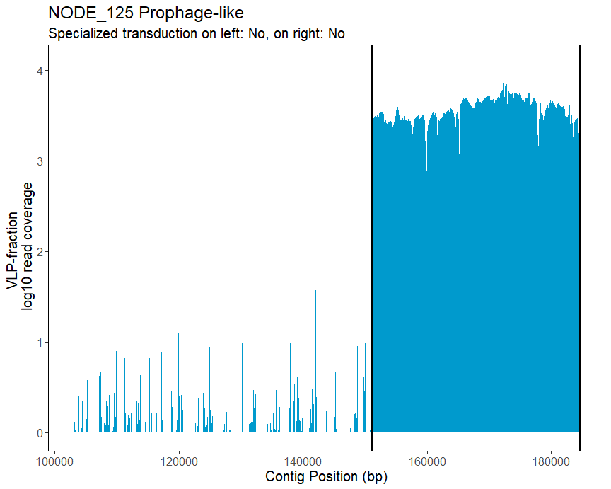

```r
Specialized_transduction$Plots
```

View a specific plot:

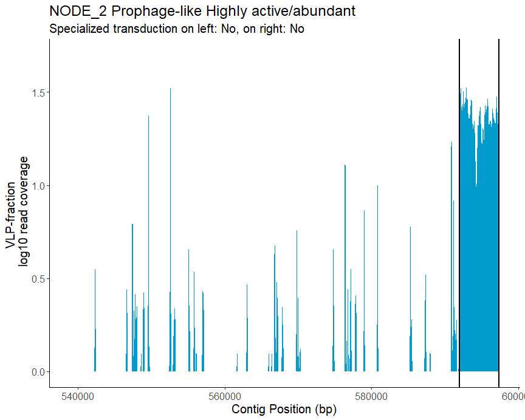

```r
Specialized_transduction$Plots$NODE_2
```

###### Non-default:

We suggest using the default values for searching all Prophage-like contigs and only changing the `noreadcov` and `spectranslength` arguments when adapting the specialized transduction search for specific contigs. See examples below:

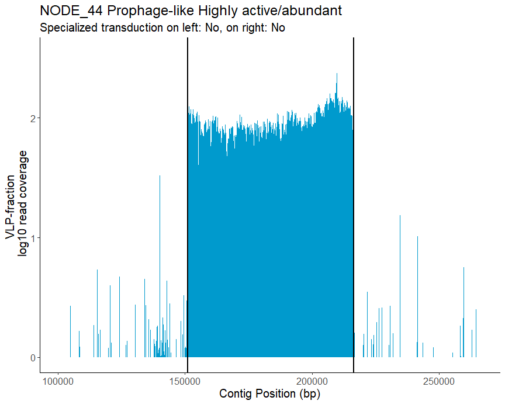

```r
Specialized_transduction_NODE44 <- SpecializedTransduction_ID(VLPFraction_sampledata, TrIdent_results, "NODE_44", spectranslength=4000)
Specialized_transduction_NODE44
```

NODE_2 has a small amount of dense read coverage outside of its left border which one might consider potential specialized transduction. `SpecializedTransduction_ID()` does not identify this as specialized transduction because there is a 500 bp (`noreadcov` default) region of no read coverage which stops the specialized transduction search. To change this, the user might increase the `noreadcov`.

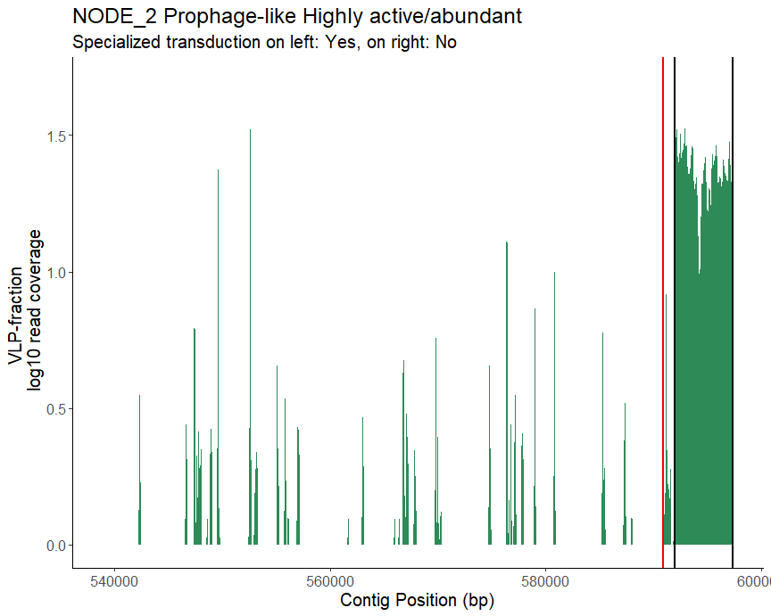

```r
Specialized_transduction_NODE2 <- SpecializedTransduction_ID(VLPFraction_sampledata, TrIdent_results, "NODE_2", noreadcov=900)
Specialized_transduction_NODE2
```

### Create final summary table:

If you’d like to combine the summary tables produced by `TrIdent_Classifier()` and `SpecializedTransduction_ID()`, try the following code:

```r
Final_TrIdentSummaryTable <- merge(TrIdent_summary_table, SpecializedTransduction_summary_table, by="ref_name", all.x=TRUE)
```

| ref_name | classifications | match_size | active_prophage | Specialized_transduction | Left | Right |
| --- | --- | --- | --- | --- | --- | --- |
| NODE_1088 | HighVLPWCReadCov | NA | NA | NA | NA | NA |
| NODE_125 | Prophage-like | 31000 | NO | no | no | no |
| NODE_2 | Prophage-like | 8000 | YES | no | no | no |
| NODE_238 | Gen/Lat/GTA | 146000 | NA | NA | NA | NA |
| NODE_25 | None | NA | NA | NA | NA | NA |
| NODE_251 | Gen/Lat/GTA | 144000 | NA | NA | NA | NA |
| NODE_44 | Prophage-like | 65000 | YES | yes | yes | no |
| NODE_560 | HighVLPWCReadCov | NA | NA | NA | NA | NA |
| NODE_62 | Prophage-like | 171000 | YES | yes | yes | no |